# Estadística Multidimensional — Análisis Exploratorio Integral

```
--------------------------------------------------
Análisis para la variable:  Credit_Limit
--------------------------------------------------
          Q1.Q1           Q3.Q3          RIC.Q3 Lim_Inferior.Q1 Lim_Superior.Q3
         157000          779000          622000         -776000         1712000
Conteo de atípicos univariados:
N_Atipicos Porcentaje
  4173.000      8.346
```

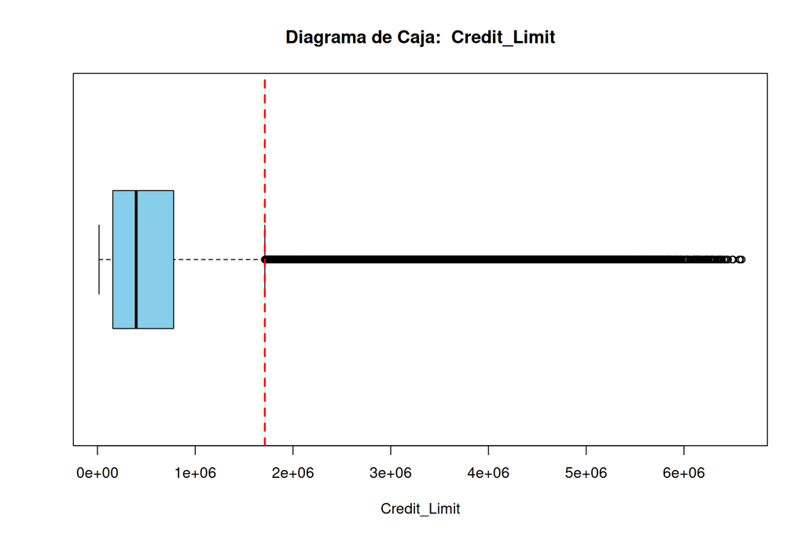

```
--------------------------------------------------
Análisis para la variable:  Card_Age_Months
--------------------------------------------------
          Q1.Q1           Q3.Q3          RIC.Q3 Lim_Inferior.Q1 Lim_Superior.Q3
           31.0            70.0            39.0           -27.5           128.5
Conteo de atípicos univariados:
N_Atipicos Porcentaje
  1287.000      2.574
```

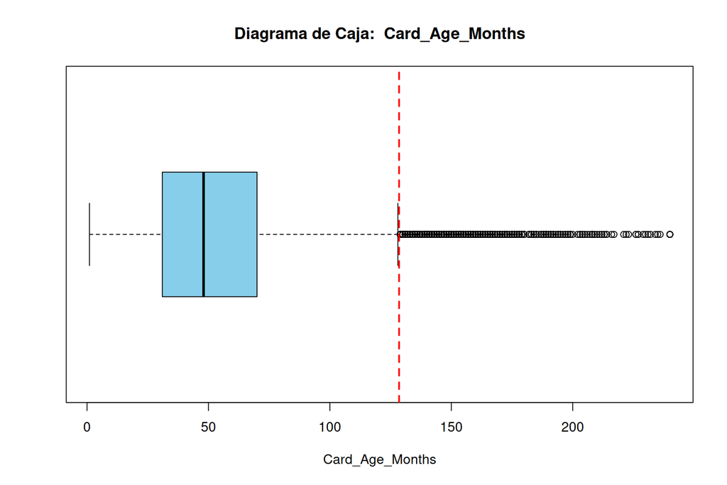

**Card_Age_Months** mide la antigüedad de la tarjeta en meses. Hay más tarjetas nuevas que antiguas, así que la masa se acumula en los primeros años y decae hacia los 240 meses: es el perfil de una cartera que sigue creciendo y captando clientes. La regla de Tukey deja 1.287 datos fuera de los bigotes (2.57%), todos en la cola derecha; no son errores de captura sino la parte extrema de esa misma cola.

```
--------------------------------------------------
Análisis para la variable:  Monthly_Spending
--------------------------------------------------
          Q1.Q1           Q3.Q3          RIC.Q3 Lim_Inferior.Q1 Lim_Superior.Q3
       26646.33        83032.36        56386.03       -57932.71       167611.40
Conteo de atípicos univariados:
N_Atipicos Porcentaje
  4213.000      8.426
```

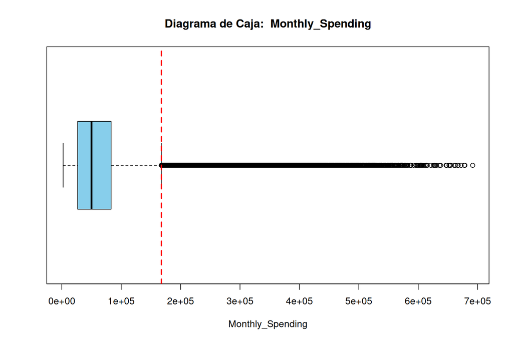

**Monthly_Spending** mide el gasto mensual total, que es la suma de las siete categorías de consumo. Al ser la suma de siete categorías que ya vienen sesgadas a la derecha, acumula todas esas colas: la mayoría gasta cerca de la mediana y un grupo pequeño gasta un orden de magnitud más. La regla de Tukey deja 4.213 datos fuera de los bigotes (8.43%), todos en la cola derecha; no son errores de captura sino la parte extrema de esa misma cola.

```
--------------------------------------------------
Análisis para la variable:  Monthly_Transactions
--------------------------------------------------
          Q1.Q1           Q3.Q3          RIC.Q3 Lim_Inferior.Q1 Lim_Superior.Q3
           49.0           108.0            59.0           -39.5           196.5
Conteo de atípicos univariados:
N_Atipicos Porcentaje
         0          0
```

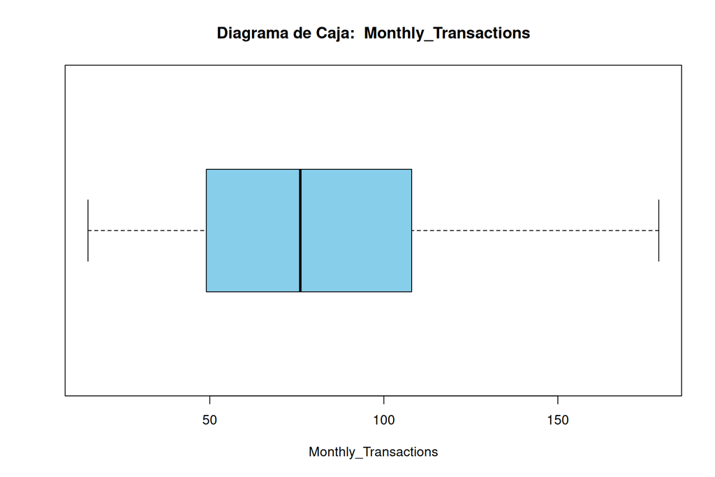

**Monthly_Transactions** mide el número de compras realizadas en el mes. Es un conteo acotado por lo que una persona alcanza a hacer en un mes (entre 15 y 179 compras), por eso la forma es prácticamente simétrica y sin colas largas. La regla de Tukey no marca ningún dato fuera de los bigotes: la variable está acotada por su propia naturaleza.

```
--------------------------------------------------
Análisis para la variable:  Avg_Transaction_Value
--------------------------------------------------
          Q1.Q1           Q3.Q3          RIC.Q3 Lim_Inferior.Q1 Lim_Superior.Q3
         448.37          901.27          452.90         -230.98         1580.62
Conteo de atípicos univariados:
N_Atipicos Porcentaje
  4286.000      8.572
```

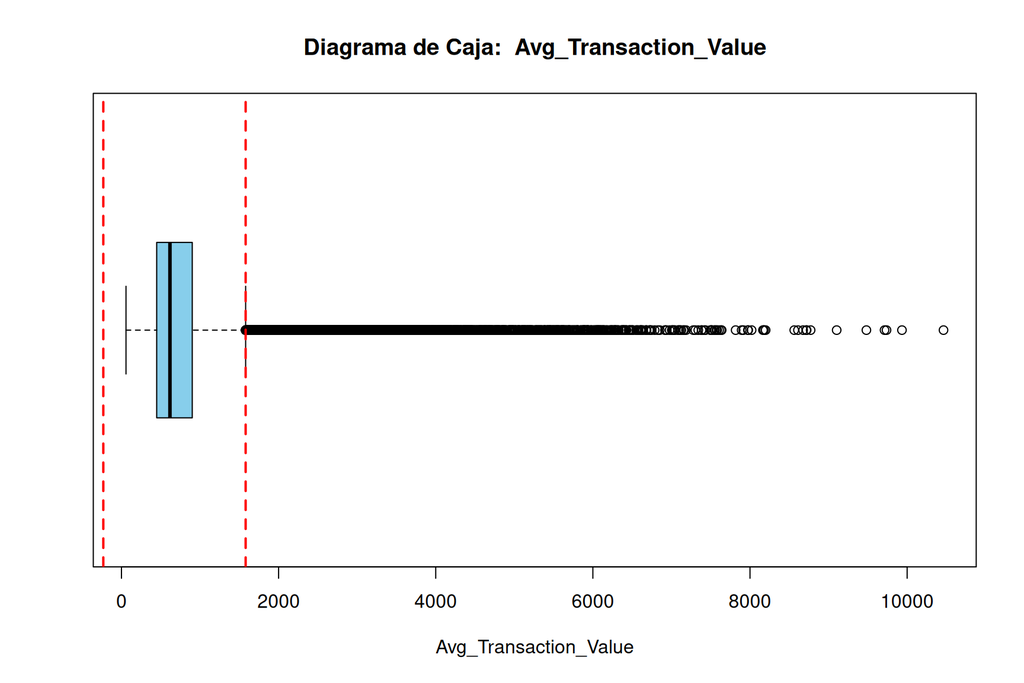

**Avg_Transaction_Value** mide el ticket promedio, es decir el gasto mensual dividido entre el número de transacciones. Es un cociente entre dos variables, y como el numerador tiene cola derecha y el denominador está acotado, el resultado queda fuertemente sesgado: dominan los tickets pequeños del día a día y unos pocos compradores de tickets altos estiran la cola. La regla de Tukey deja 4.286 datos fuera de los bigotes (8.57%), todos en la cola derecha; no son errores de captura sino la parte extrema de esa misma cola.

```
--------------------------------------------------
Análisis para la variable:  Online_Shopping_Spending
--------------------------------------------------
          Q1.Q1           Q3.Q3          RIC.Q3 Lim_Inferior.Q1 Lim_Superior.Q3
       2800.675       12820.420       10019.745      -12228.942       27850.037
Conteo de atípicos univariados:
N_Atipicos Porcentaje
   4045.00       8.09
```

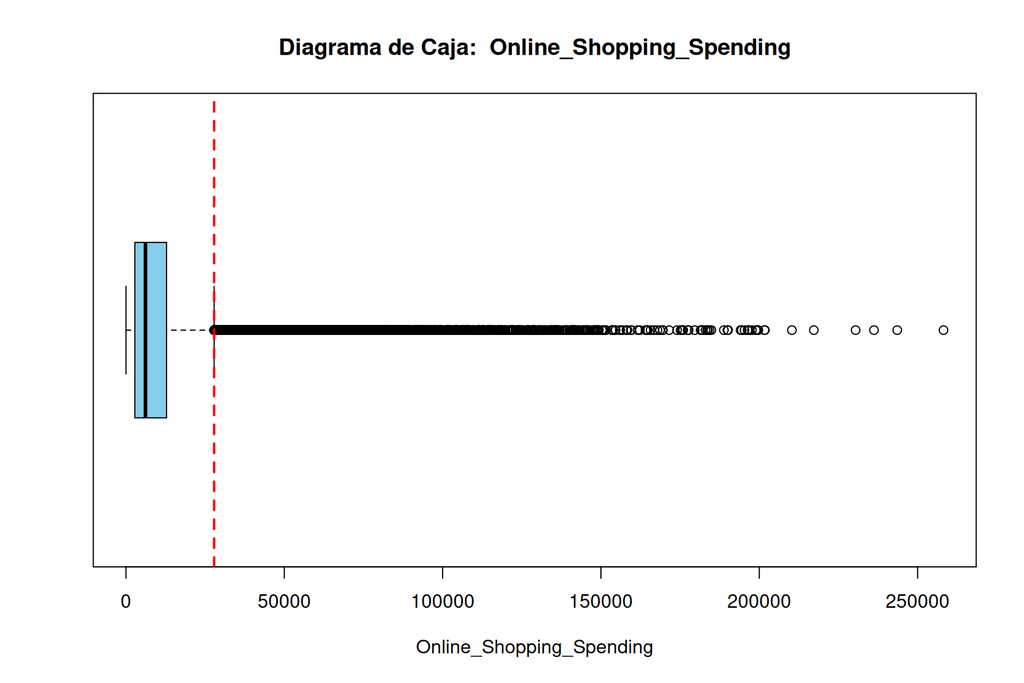

**Online_Shopping_Spending** mide el gasto mensual en compras por internet. Como todo gasto por categoría, la mayoría de clientes gasta poco y unos pocos gastan mucho, lo que produce el pico pegado al origen y la cola larga hacia la derecha. La regla de Tukey deja 4.045 datos fuera de los bigotes (8.09%), todos en la cola derecha; no son errores de captura sino la parte extrema de esa misma cola.

```
--------------------------------------------------
Análisis para la variable:  Grocery_Spending
--------------------------------------------------
          Q1.Q1           Q3.Q3          RIC.Q3 Lim_Inferior.Q1 Lim_Superior.Q3
       5176.815       20419.725       15242.910      -17687.550       43284.090
Conteo de atípicos univariados:
N_Atipicos Porcentaje
  4032.000      8.064
```

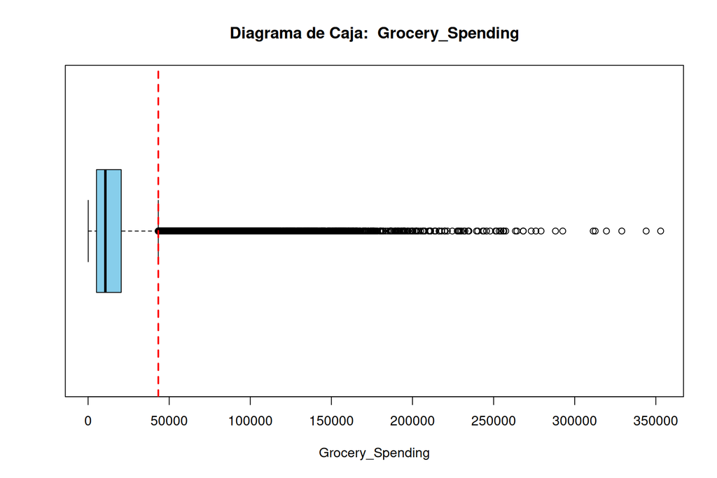

**Grocery_Spending** mide el gasto mensual en supermercado. Es la categoría con la mediana más alta de todas: el mercado es un gasto recurrente que casi todos hacen, por eso el pico está más desplazado del origen que en las demás categorías, aunque conserva la cola derecha. La regla de Tukey deja 4.032 datos fuera de los bigotes (8.06%), todos en la cola derecha; no son errores de captura sino la parte extrema de esa misma cola.

```
--------------------------------------------------
Análisis para la variable:  Fuel_Spending
--------------------------------------------------
          Q1.Q1           Q3.Q3          RIC.Q3 Lim_Inferior.Q1 Lim_Superior.Q3
       2432.140       11560.985        9128.845      -11261.128       25254.253
Conteo de atípicos univariados:
N_Atipicos Porcentaje
  4176.000      8.352
```

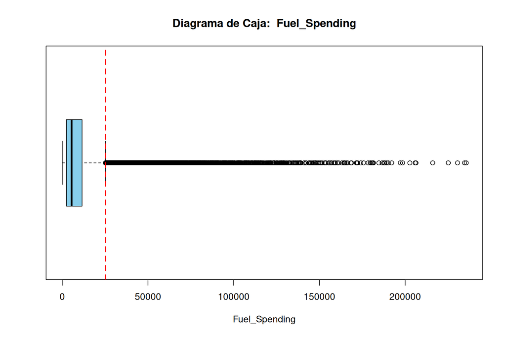

**Fuel_Spending** mide el gasto mensual en combustible. El gasto en combustible depende de si el cliente tiene vehículo y cuánto se desplaza, así que convive un grupo grande de gasto bajo con una minoría de gasto alto que alarga la cola. La regla de Tukey deja 4.176 datos fuera de los bigotes (8.35%), todos en la cola derecha; no son errores de captura sino la parte extrema de esa misma cola.

```
--------------------------------------------------
Análisis para la variable:  Dining_Spending
--------------------------------------------------
          Q1.Q1           Q3.Q3          RIC.Q3 Lim_Inferior.Q1 Lim_Superior.Q3
       2089.505       10381.865        8292.360      -10349.035       22820.405
Conteo de atípicos univariados:
N_Atipicos Porcentaje
  4202.000      8.404
```

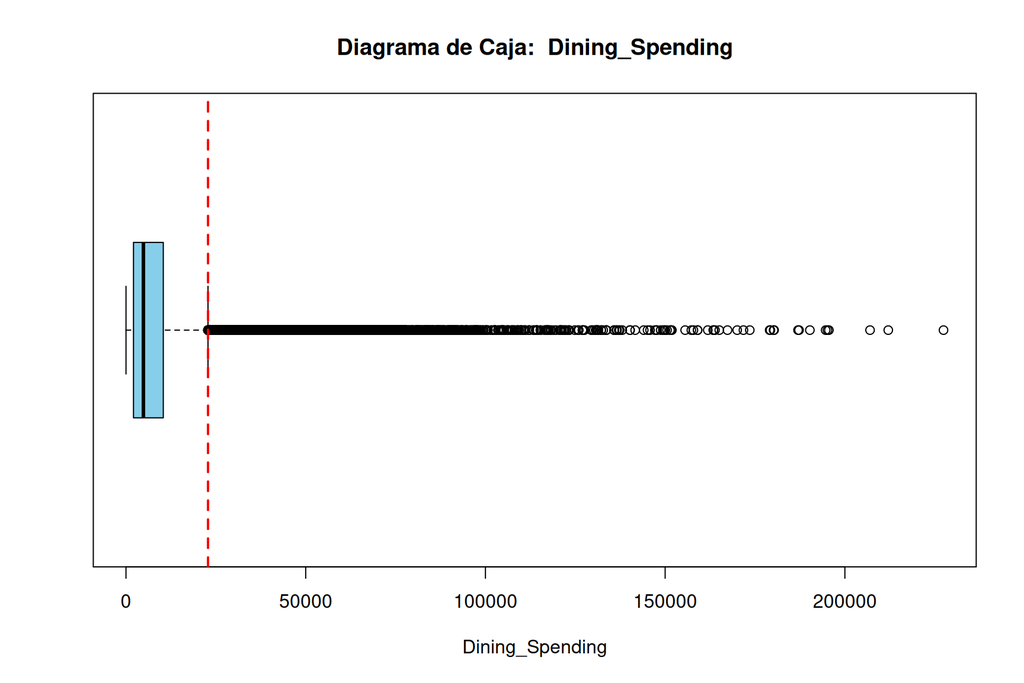

**Dining_Spending** mide el gasto mensual en restaurantes. Comer fuera es un gasto discrecional: la mayoría lo hace de forma moderada y una minoría concentra montos muy altos, de ahí el sesgo pronunciado a la derecha. La regla de Tukey deja 4.202 datos fuera de los bigotes (8.40%), todos en la cola derecha; no son errores de captura sino la parte extrema de esa misma cola.

```
--------------------------------------------------
Análisis para la variable:  Travel_Spending
--------------------------------------------------
          Q1.Q1           Q3.Q3          RIC.Q3 Lim_Inferior.Q1 Lim_Superior.Q3
       1076.960        6862.885        5785.925       -7601.928       15541.773
Conteo de atípicos univariados:
N_Atipicos Porcentaje
   4315.00       8.63
```

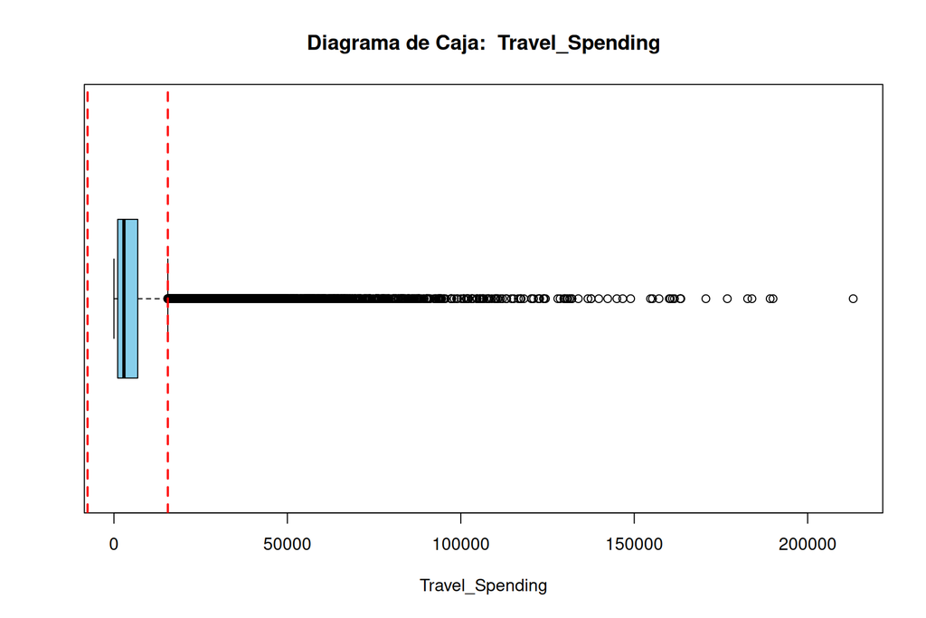

**Travel_Spending** mide el gasto mensual en viajes. Es el gasto más esporádico de todos (la mediana es la más baja de las categorías): la mayoría viaja poco o nada en el mes, y los pocos que viajan lo hacen con montos grandes, lo que produce la cola más larga del grupo. La regla de Tukey deja 4.315 datos fuera de los bigotes (8.63%), todos en la cola derecha; no son errores de captura sino la parte extrema de esa misma cola.

```
--------------------------------------------------
Análisis para la variable:  Entertainment_Spending
--------------------------------------------------
          Q1.Q1           Q3.Q3          RIC.Q3 Lim_Inferior.Q1 Lim_Superior.Q3
       1570.085        8612.840        7042.755       -8994.048       19176.972
Conteo de atípicos univariados:
N_Atipicos Porcentaje
  4276.000      8.552
```

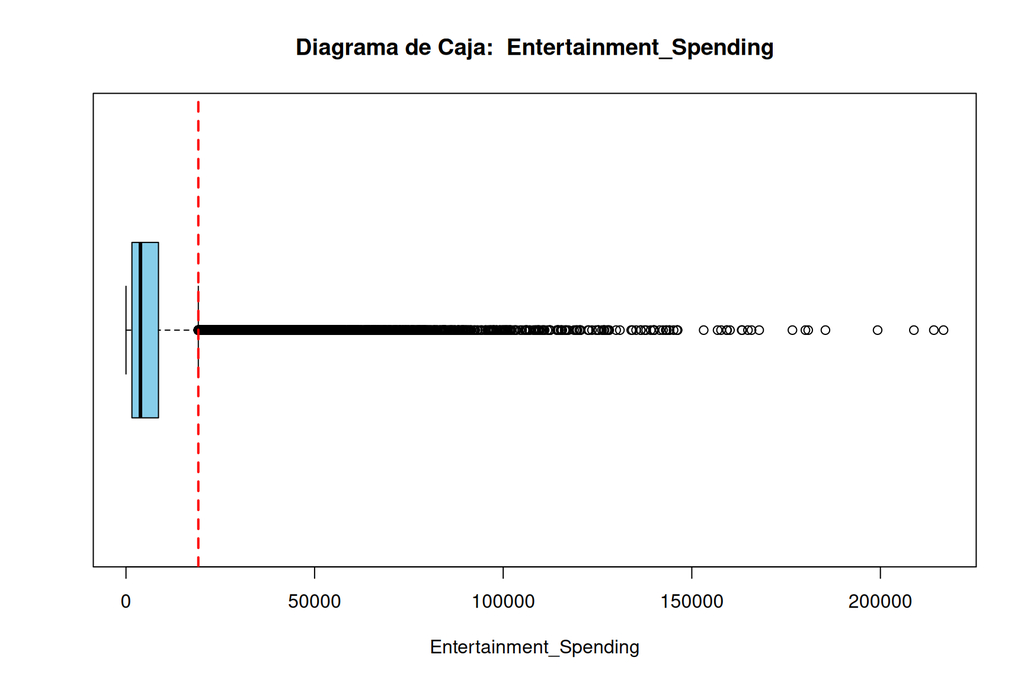

**Entertainment_Spending** mide el gasto mensual en entretenimiento. Gasto discrecional y ocasional: se concentra en montos bajos con una cola derecha marcada correspondiente a quienes consumen ocio de forma intensiva. La regla de Tukey deja 4.276 datos fuera de los bigotes (8.55%), todos en la cola derecha; no son errores de captura sino la parte extrema de esa misma cola.

```
--------------------------------------------------
Análisis para la variable:  Utility_Bill_Spending
--------------------------------------------------
          Q1.Q1           Q3.Q3          RIC.Q3 Lim_Inferior.Q1 Lim_Superior.Q3
        2978.38        13510.05        10531.67       -12819.12        29307.54
Conteo de atípicos univariados:
N_Atipicos Porcentaje
  4056.000      8.112
```

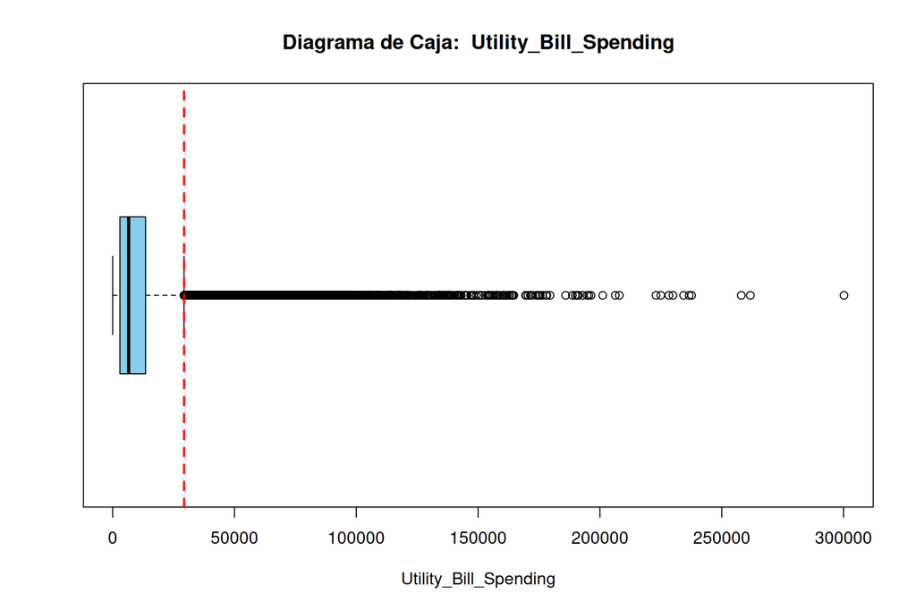

**Utility_Bill_Spending** mide el gasto mensual en servicios públicos pagados con la tarjeta. Domiciliar los servicios públicos en la tarjeta es una práctica frecuente pero de monto acotado, así que la masa está en valores bajos y la cola derecha viene de hogares con facturas altas. La regla de Tukey deja 4.056 datos fuera de los bigotes (8.11%), todos en la cola derecha; no son errores de captura sino la parte extrema de esa misma cola.

```
--------------------------------------------------
Análisis para la variable:  Outstanding_Balance
--------------------------------------------------
          Q1.Q1           Q3.Q3          RIC.Q3 Lim_Inferior.Q1 Lim_Superior.Q3
       55640.71       319985.76       264345.05      -340876.85       716503.33
Conteo de atípicos univariados:
N_Atipicos Porcentaje
   4570.00       9.14
```

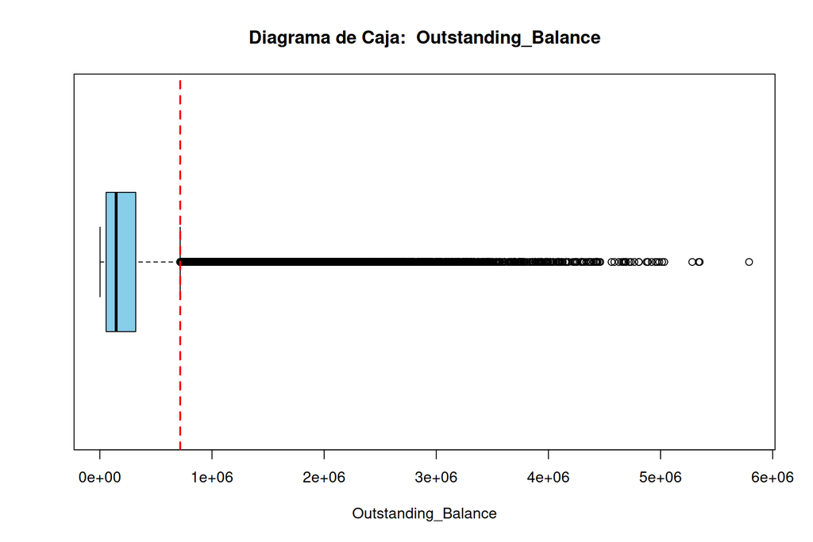

**Outstanding_Balance** mide el saldo que el cliente aún debe. La deuda pendiente sigue la misma lógica del gasto y del cupo: casi todos deben montos moderados y unos pocos arrastran saldos muy grandes, lo que estira la cola derecha. La regla de Tukey deja 4.570 datos fuera de los bigotes (9.14%), todos en la cola derecha; no son errores de captura sino la parte extrema de esa misma cola.

```
--------------------------------------------------
Análisis para la variable:  Statement_Balance
--------------------------------------------------
          Q1.Q1           Q3.Q3          RIC.Q3 Lim_Inferior.Q1 Lim_Superior.Q3
        82467.3        387442.0        304974.7       -374994.8        844904.1
Conteo de atípicos univariados:
N_Atipicos Porcentaje
  4591.000      9.182
```

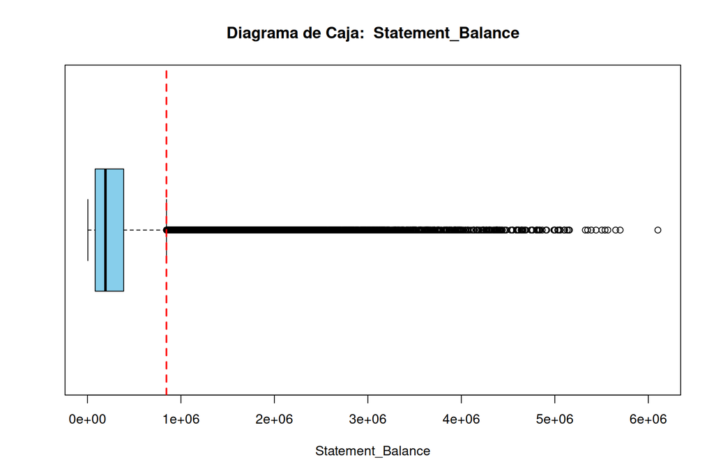

**Statement_Balance** mide el saldo facturado en el último corte del extracto. Es prácticamente la misma magnitud que el saldo pendiente medida en el corte de facturación, por eso su forma es casi idéntica a la de aquella variable. La regla de Tukey deja 4.591 datos fuera de los bigotes (9.18%), todos en la cola derecha; no son errores de captura sino la parte extrema de esa misma cola.

```
--------------------------------------------------
Análisis para la variable:  Payment_Amount
--------------------------------------------------
          Q1.Q1           Q3.Q3          RIC.Q3 Lim_Inferior.Q1 Lim_Superior.Q3
       55193.18       299100.96       243907.77      -310668.47       664962.61
Conteo de atípicos univariados:
N_Atipicos Porcentaje
   4535.00       9.07
```

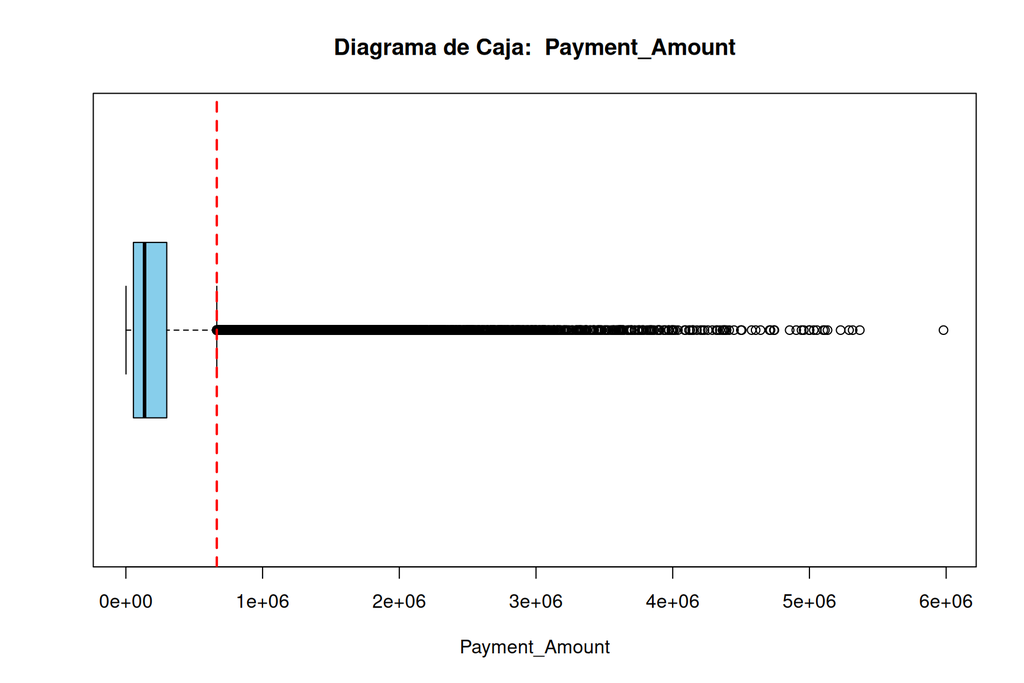

**Payment_Amount** mide el monto que el cliente pagó en el mes. El pago es proporcional a lo facturado, así que reproduce la forma sesgada del saldo: pagos moderados en la mayoría y pagos muy grandes en la minoría con saldos altos. La regla de Tukey deja 4.535 datos fuera de los bigotes (9.07%), todos en la cola derecha; no son errores de captura sino la parte extrema de esa misma cola.

```
--------------------------------------------------
Análisis para la variable:  Payment_Ratio
--------------------------------------------------
          Q1.Q1           Q3.Q3          RIC.Q3 Lim_Inferior.Q1 Lim_Superior.Q3
           0.62            0.96            0.34            0.11            1.47
Conteo de atípicos univariados:
N_Atipicos Porcentaje
    87.000      0.174
```

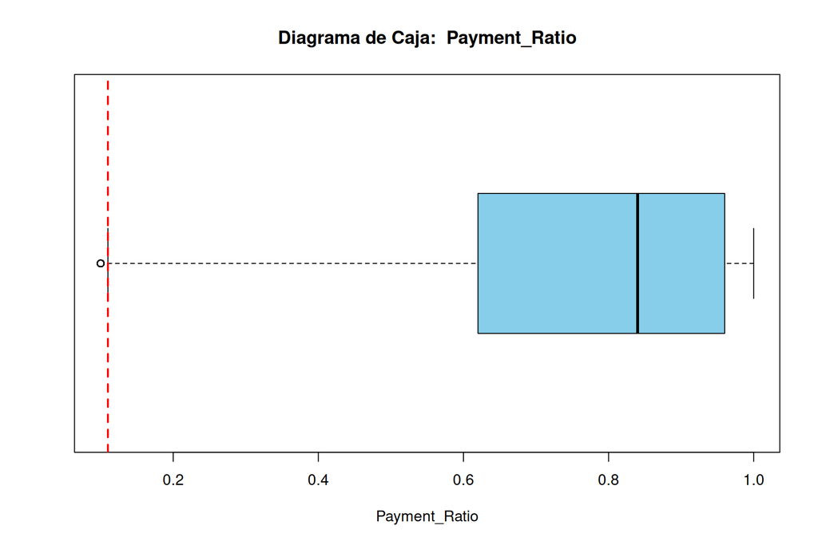

```
--------------------------------------------------
Análisis para la variable:  Credit_Utilization
--------------------------------------------------
          Q1.Q1           Q3.Q3          RIC.Q3 Lim_Inferior.Q1 Lim_Superior.Q3
          0.270           0.560           0.290          -0.165           0.995
Conteo de atípicos univariados:
N_Atipicos Porcentaje
         0          0
```

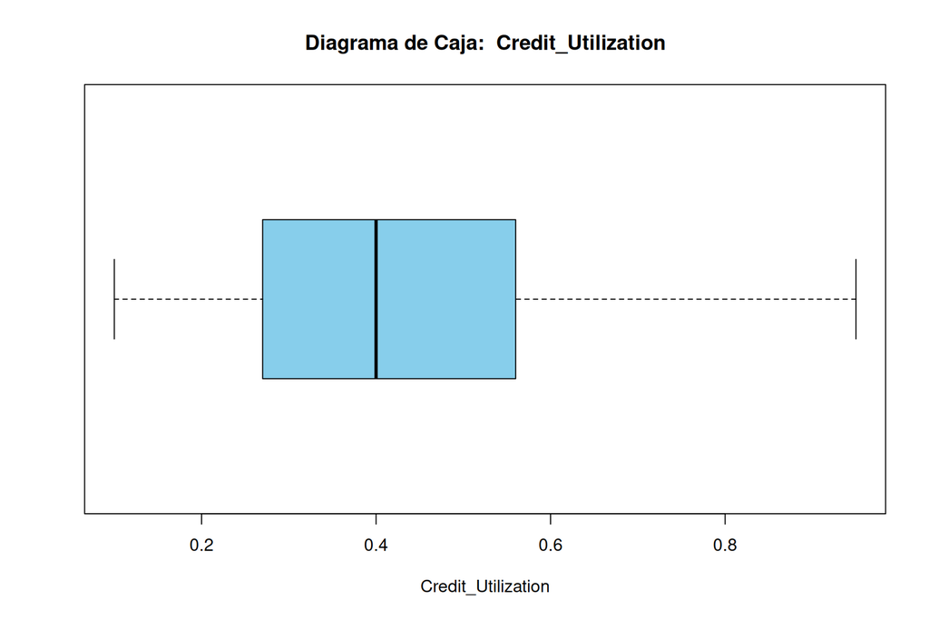

**Credit_Utilization** mide la proporción del cupo que el cliente tiene usada. Es una proporción acotada entre 0 y 1 por construcción, y las políticas de cupo evitan que los clientes lleguen al tope, por eso la forma es compacta, sin colas y sin ningún dato fuera de los bigotes. La regla de Tukey no marca ningún dato fuera de los bigotes: la variable está acotada por su propia naturaleza.

```
--------------------------------------------------
Análisis para la variable:  Cash_Advance_Amount
--------------------------------------------------
          Q1.Q1           Q3.Q3          RIC.Q3 Lim_Inferior.Q1 Lim_Superior.Q3
           0.00         8692.19         8692.19       -13038.28        21730.47
Conteo de atípicos univariados:
N_Atipicos Porcentaje
  9549.000     19.098
```

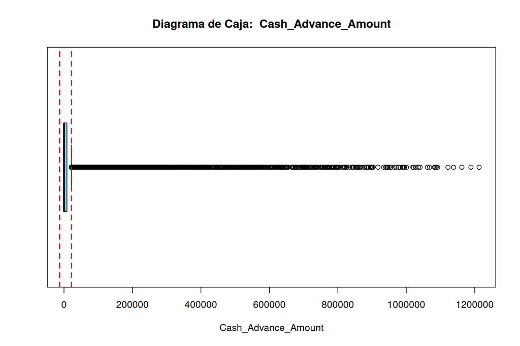

**Cash_Advance_Amount** mide el monto retirado como avance en efectivo. Más de la mitad de los clientes nunca hace avances, así que la distribución tiene un bloque enorme en cero y una cola larga formada por la minoría que sí los usa: es una variable inflada en cero, no una distribución continua clásica. La regla de Tukey deja 9.549 datos fuera de los bigotes (19.10%), todos en la cola derecha; no son errores de captura sino la parte extrema de esa misma cola.

```
--------------------------------------------------
Análisis para la variable:  EMI_Count
--------------------------------------------------
          Q1.Q1           Q3.Q3          RIC.Q3 Lim_Inferior.Q1 Lim_Superior.Q3
            1.0             4.0             3.0            -3.5             8.5
Conteo de atípicos univariados:
N_Atipicos Porcentaje
         0          0
```

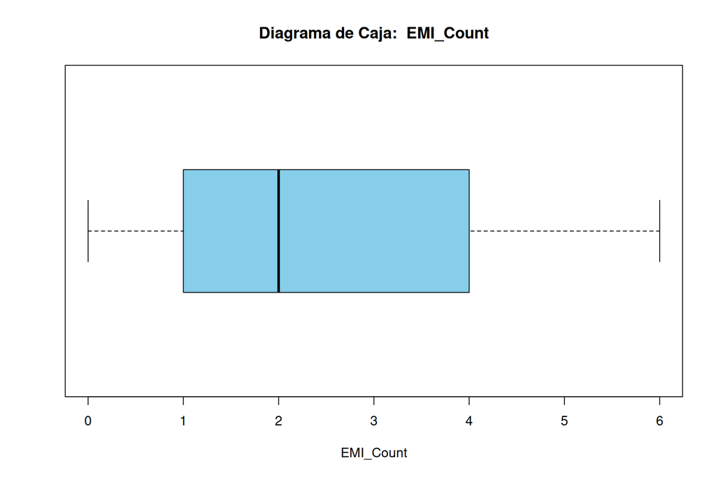

```
--------------------------------------------------
Análisis para la variable:  International_Transactions
--------------------------------------------------
          Q1.Q1           Q3.Q3          RIC.Q3 Lim_Inferior.Q1 Lim_Superior.Q3
              0               2               2              -3               5
Conteo de atípicos univariados:
N_Atipicos Porcentaje
  4769.000      9.538
```

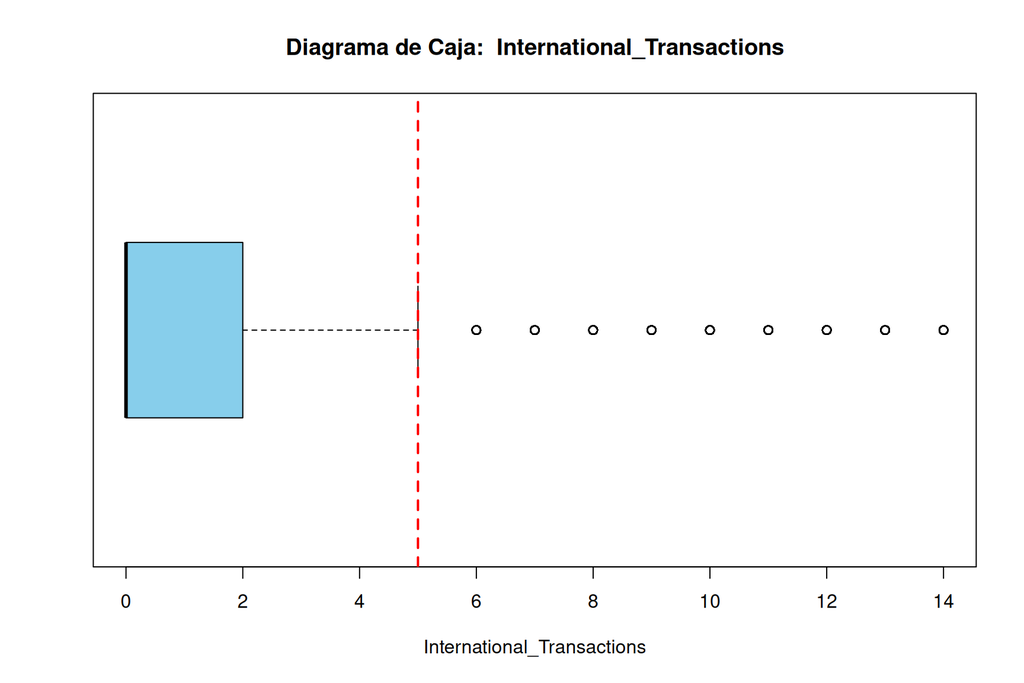

```
--------------------------------------------------
Análisis para la variable:  Reward_Points_Earned
--------------------------------------------------
          Q1.Q1           Q3.Q3          RIC.Q3 Lim_Inferior.Q1 Lim_Superior.Q3
          720.0          3767.0          3047.0         -3850.5          8337.5
Conteo de atípicos univariados:
N_Atipicos Porcentaje
   4930.00       9.86
```

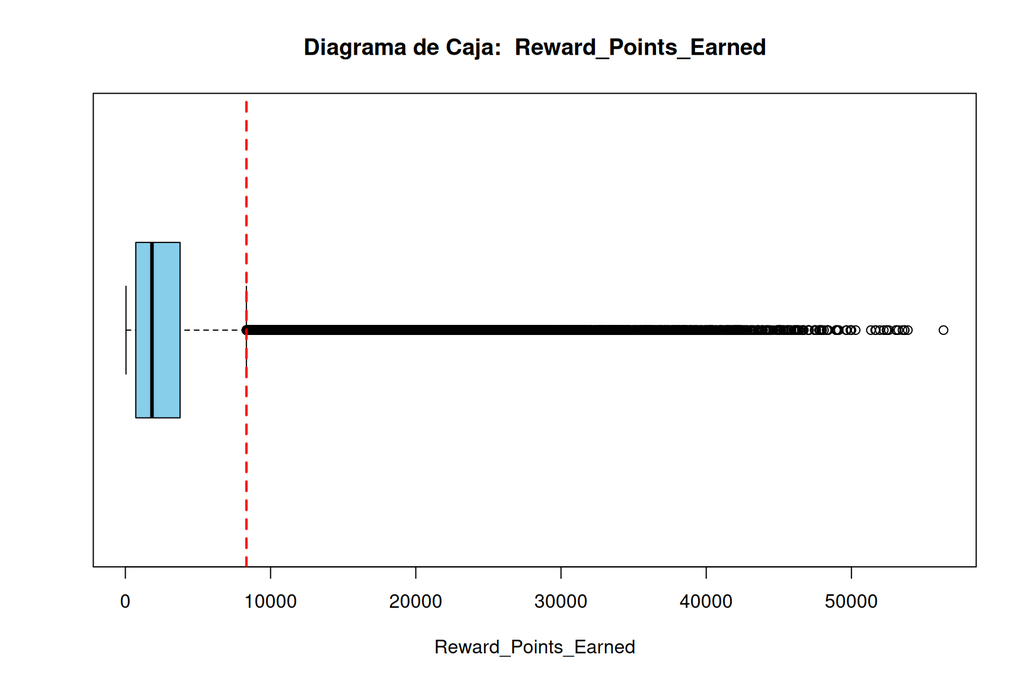

**Reward_Points_Earned** mide los puntos de recompensa acumulados, que el banco calcula a partir del gasto. Los puntos se calculan como función del gasto, así que la gráfica es esencialmente la del gasto mensual reescalada: mismo pico bajo y misma cola derecha. La regla de Tukey deja 4.930 datos fuera de los bigotes (9.86%), todos en la cola derecha; no son errores de captura sino la parte extrema de esa misma cola.

```
--------------------------------------------------
Análisis para la variable:  Reward_Points_Redeemed
--------------------------------------------------
          Q1.Q1           Q3.Q3          RIC.Q3 Lim_Inferior.Q1 Lim_Superior.Q3
            0.0           731.0           731.0         -1096.5          1827.5
Conteo de atípicos univariados:
N_Atipicos Porcentaje
  5708.000     11.416
```

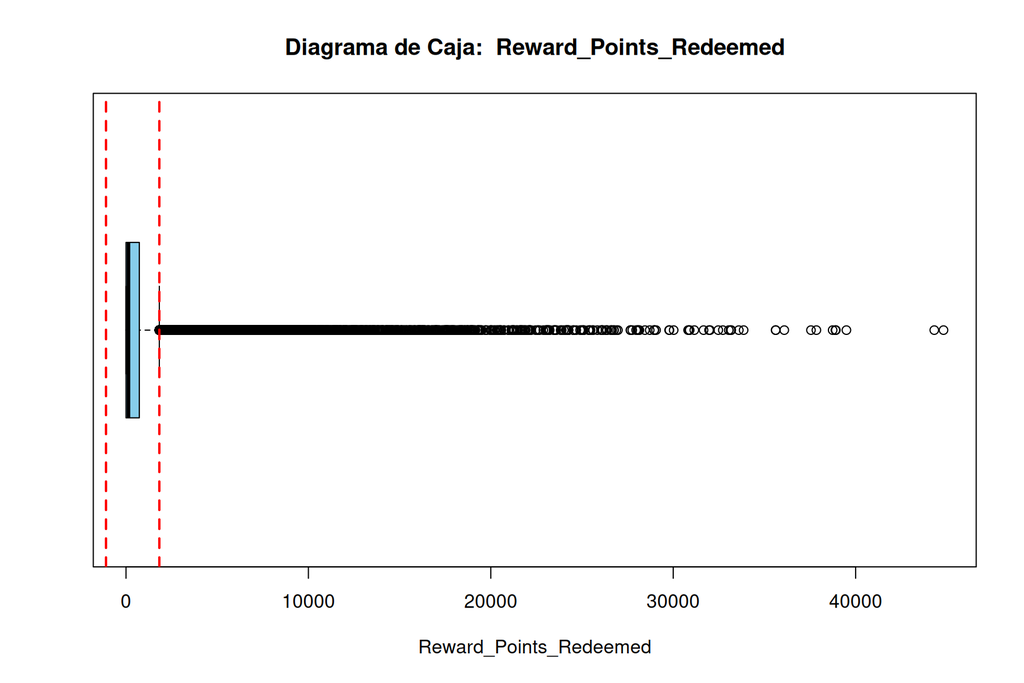

**Reward_Points_Redeemed** mide los puntos de recompensa que el cliente ya redimió. Muchos clientes acumulan puntos pero no los redimen, por eso hay una acumulación en cero y una cola derecha correspondiente a quienes sí los usan, normalmente en redenciones grandes y puntuales. La regla de Tukey deja 5.708 datos fuera de los bigotes (11.42%), todos en la cola derecha; no son errores de captura sino la parte extrema de esa misma cola.

```
--------------------------------------------------
Análisis para la variable:  Mobile_App_Login
--------------------------------------------------
          Q1.Q1           Q3.Q3          RIC.Q3 Lim_Inferior.Q1 Lim_Superior.Q3
             20              44              24             -16              80
Conteo de atípicos univariados:
N_Atipicos Porcentaje
         0          0
```

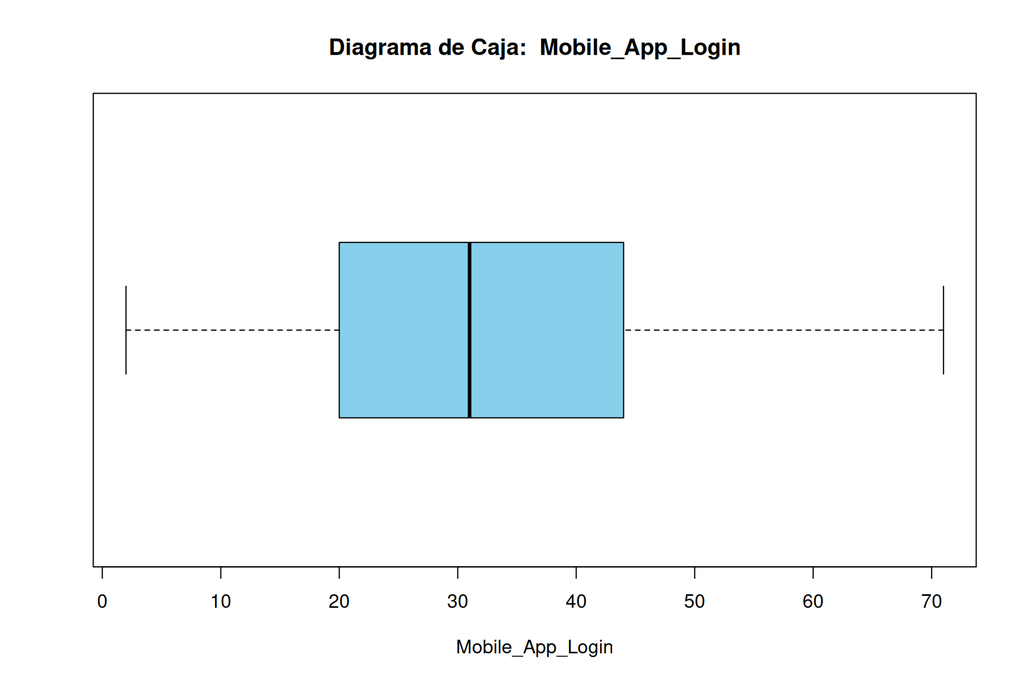

**Mobile_App_Login** mide el número de ingresos del cliente a la aplicación móvil en el mes. Es un conteo acotado de sesiones al mes (entre 2 y 71) y refleja un hábito de consulta bastante uniforme, así que la forma es casi simétrica y sin atípicos. La regla de Tukey no marca ningún dato fuera de los bigotes: la variable está acotada por su propia naturaleza.

```
--------------------------------------------------
Análisis para la variable:  Credit_Score
--------------------------------------------------
          Q1.Q1           Q3.Q3          RIC.Q3 Lim_Inferior.Q1 Lim_Superior.Q3
            585             681              96             441             825
Conteo de atípicos univariados:
N_Atipicos Porcentaje
   394.000      0.788
```

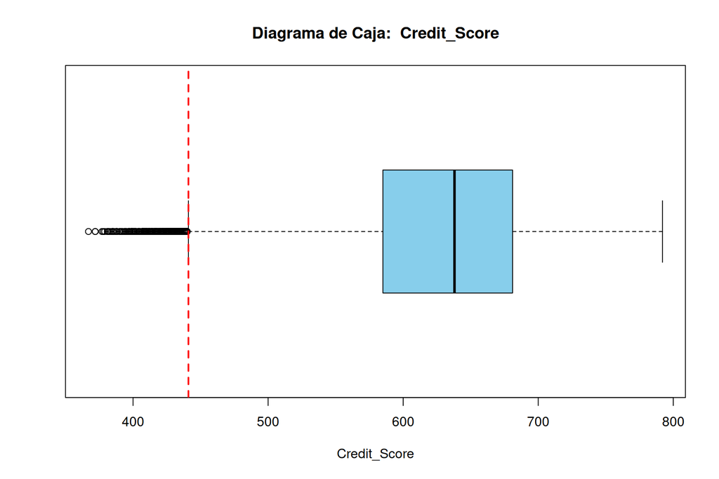

**Credit_Score** mide el puntaje crediticio asignado al cliente. El puntaje está acotado por diseño en un rango estrecho y la mayoría de clientes cae en la zona media-alta; la cola corta hacia la izquierda corresponde a la minoría de perfiles de alto riesgo. La regla de Tukey deja 394 datos fuera de los bigotes (0.79%), todos en la cola izquierda; no son errores de captura sino la parte extrema de esa misma cola.

# 6 Módulo 5: Comparación Multivariada Estandarizada mediante Boxplots (S03)

Cuando tenemos múltiples variables cuantitativas en diferentes unidades (pesos, meses, transacciones, ratios), no es posible graficarlas juntas en su escala original.

```r
cols_num <- sapply(credit, is.numeric)
credit_num <- credit[, cols_num]
```

## 6.1 Boxplots sin estandarizar vs. estandarizados (`scale`)

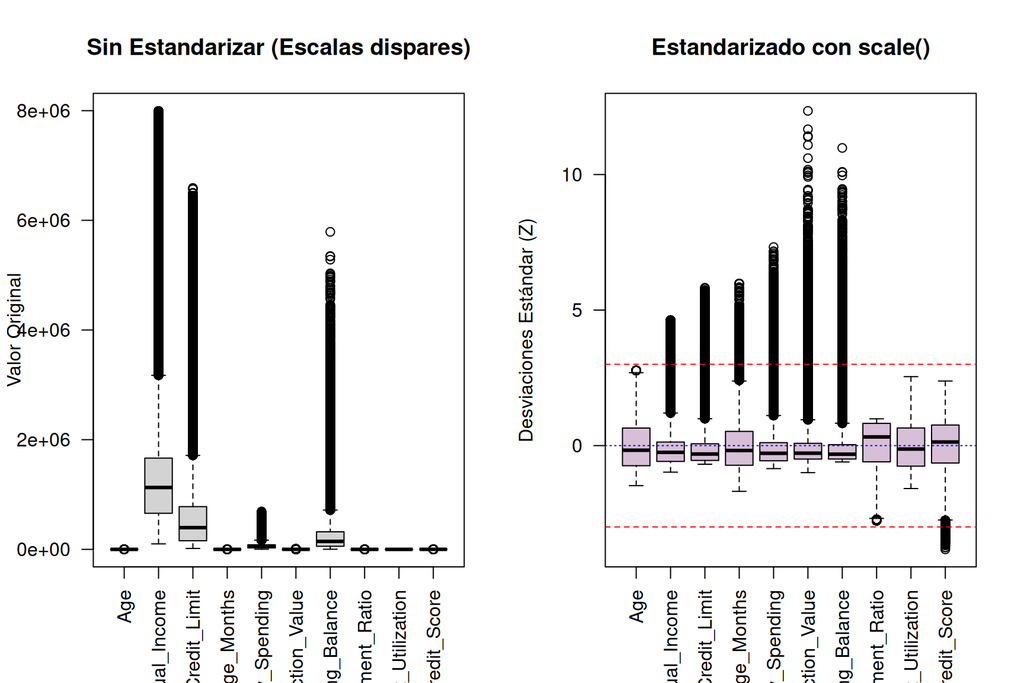

```r
# Seleccionamos un subconjunto representativo de variables para visualización clara
vars_box <- c("Age", "Annual_Income", "Credit_Limit", "Card_Age_Months",
              "Monthly_Spending", "Avg_Transaction_Value", "Outstanding_Balance",
              "Payment_Ratio", "Credit_Utilization", "Credit_Score")

par(mfrow = c(1, 2))

# 1. Sin estandarizar (las variables en millones dominan y ocultan a los ratios)
boxplot(credit_num[, vars_box], las = 2, col = "lightgray",
        main = "Sin Estandarizar (Escalas dispares)",
        ylab = "Valor Original")

# 2. Estandarizado (Z-scores: media 0, varianza 1)
credit_scale <- scale(credit_num[, vars_box])
boxplot(credit_scale, las = 2, col = "thistle",
        main = "Estandarizado con scale()",
        ylab = "Desviaciones Estándar (Z)")
abline(h = 0, col = "blue", lty = 3)
abline(h = c(-3, 3), col = "red", lty = 2)
```

```r
par(mfrow = c(1, 1))
```

## 6.2 Diagnóstico de colas máximas ($Z$-score máximo)

Identificamos a cuántas desviaciones estándar de su media se encuentra el valor máximo de cada variable:

```r
z_max <- apply(credit_scale, 2, max)
round(sort(z_max, decreasing = TRUE), 2)
```

```
#> Avg_Transaction_Value   Outstanding_Balance      Monthly_Spending
#>                 12.35                 10.98                  7.33
#>       Card_Age_Months          Credit_Limit         Annual_Income
#>                  5.97                  5.82                  4.63
#>                   Age    Credit_Utilization          Credit_Score
#>                  2.77                  2.54                  2.38
#>         Payment_Ratio
#>                  0.99
```

> **Lección de la Semana 3:** La estandarización `scale()` nivela el terreno de juego, permitiendo comparar simultáneamente la dispersión y la longitud relativa de las colas entre variables con órdenes de magnitud dispares ($10^6$ vs $10^{-1}$).

# 7 Módulo 6: Análisis Bivariado, Correlación y el “Punto Imposible” (S01 & S03)

## 7.1 Correlación bivariada y dispersión

Analizamos la relación entre el Ratio de Pago (`Payment_Ratio`) y el Puntaje Crediticio (`Credit_Score`):

```r
r_pr_cs <- cor(credit$Payment_Ratio, credit$Credit_Score)
r_pr_cs
```

```
#> [1] 0.7671463
```

```r
cor(credit$Annual_Income, credit$Credit_Limit)
```

```
#> [1] 0.9741659
```

Existe una fuerte correlación lineal positiva ($r = 0.767$): los clientes que pagan una proporción mayor de su deuda exhiben sistemáticamente mejores puntajes de crédito.

## 7.2 Construcción y Demostración del “Punto Imposible” (S03 - Sesión 4)

Uno de los conceptos fundamentales que distingue la **Estadística Multivariante** de la univariada es que **un individuo puede ser perfectamente normal en cada variable por separado y, sin embargo, ser un valor atípico imposible en el espacio conjunto**.

### 7.2.1 1. Verificación de los límites univariados de Tukey

```r
f_pr <- fivenum(credit$Payment_Ratio)
f_cs <- fivenum(credit$Credit_Score)

iqr_pr <- f_pr[4] - f_pr[2]
iqr_cs <- f_cs[4] - f_cs[2]

lim_pr <- c(f_pr[2] - 1.5 * iqr_pr, f_pr[4] + 1.5 * iqr_pr)
lim_cs <- c(f_cs[2] - 1.5 * iqr_cs, f_cs[4] + 1.5 * iqr_cs)

c("Límites Payment_Ratio (Inf, Sup)" = lim_pr,
  "Límites Credit_Score (Inf, Sup)" = lim_cs)
```

```
#> Límites Payment_Ratio (Inf, Sup)1 Límites Payment_Ratio (Inf, Sup)2
#>                              0.11                              1.47
#>  Límites Credit_Score (Inf, Sup)1  Límites Credit_Score (Inf, Sup)2
#>                            441.00                            825.00
```

### 7.2.2 2. Creación del cliente hipotético contradictorio

Diseñamos un cliente con: * `Payment_Ratio = 0.95` (Paga casi el $100\%$ de su saldo). * `Credit_Score = 460` (Puntaje crediticio extremadamente bajo / de alto riesgo).

```r
punto_pr <- 0.95
punto_cs <- 460

# Verificación 1: ¿Está dentro de los límites de Tukey univariados?
dentro_pr <- punto_pr >= lim_pr[1] & punto_pr <= lim_pr[2]
dentro_cs <- punto_cs >= lim_cs[1] & punto_cs <= lim_cs[2]

data.frame(
  Variable = c("Payment_Ratio", "Credit_Score"),
  Valor = c(punto_pr, punto_cs),
  Lim_Inferior = c(lim_pr[1], lim_cs[1]),
  Lim_Superior = c(lim_pr[2], lim_cs[2]),
  Es_Normal_Univariado = c(dentro_pr, dentro_cs)
)
```

| Variable | Valor | Lim_Inferior | Lim_Superior | Es_Normal_Univariado |
| --- | --- | --- | --- | --- |
| Payment_Ratio | 0.95 | 0.11 | 1.47 | TRUE |
| Credit_Score | 460.00 | 441.00 | 825.00 | TRUE |

Ambos valores están estrictamente dentro de los bigotes univariados. Ningún filtro univariado lo marcaría como anómalo.

### 7.2.3 3. Visualización bivariada: Demostración del “Punto Rojo”

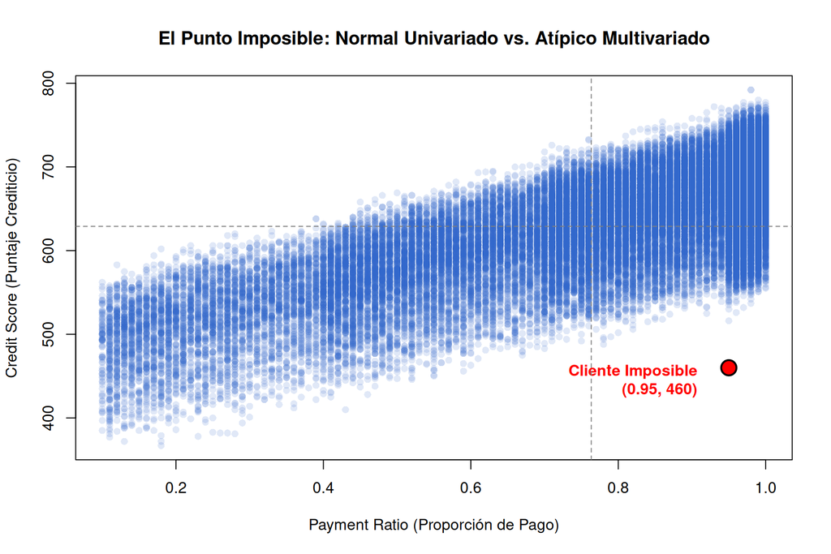

```r
plot(credit$Payment_Ratio, credit$Credit_Score,
     pch = 16, col = rgb(0.2, 0.4, 0.8, 0.15),
     xlab = "Payment Ratio (Proporción de Pago)",
     ylab = "Credit Score (Puntaje Crediticio)",
     main = "El Punto Imposible: Normal Univariado vs. Atípico Multivariado")

# Dibujamos el punto en rojo
points(punto_pr, punto_cs, col = "red", pch = 19, cex = 2.2)
points(punto_pr, punto_cs, col = "black", pch = 1, cex = 2.2, lwd = 2)
text(punto_pr - 0.03, punto_cs - 20, labels = "Cliente Imposible\n(0.95, 460)", col = "red", font = 2, pos = 2)

# Cuadrantes de referencia
abline(v = mean(credit$Payment_Ratio), col = "gray50", lty = 2)
abline(h = mean(credit$Credit_Score), col = "gray50", lty = 2)
```

```r
ingreso <- credit$Annual_Income
limite <- credit$Credit_Limit

# --- Análisis para Annual_Income ---
cat("--------------------------------------------------\n")
cat("Análisis para la variable: Annual_Income\n")
```

```
#> Análisis para la variable: Annual_Income
```

```r
cat("--------------------------------------------------\n")
f_ingreso <- fivenum(ingreso)
names(f_ingreso) <- c("Mínimo", "Q1", "Mediana", "Q3", "Máximo")

q1_ingreso <- f_ingreso["Q1"]
q3_ingreso <- f_ingreso["Q3"]
ric_ingreso <- q3_ingreso - q1_ingreso

lim_inf_ingreso <- q1_ingreso - 1.5 * ric_ingreso
lim_sup_ingreso <- q3_ingreso + 1.5 * ric_ingreso

print(c(Q1 = q1_ingreso, Q3 = q3_ingreso, RIC = ric_ingreso,
          Lim_Inferior = lim_inf_ingreso, Lim_Superior = lim_sup_ingreso))
```

```
#>           Q1.Q1           Q3.Q3          RIC.Q3 Lim_Inferior.Q1 Lim_Superior.Q3
#>        657770.5       1663677.0       1005906.5       -851089.2       3172536.8
```

```r
punto_ai <- 3000000
punto_cl <- 200

# Definir los límites de Tukey para Annual_Income y Credit_Limit
lim_ai <- c(lim_inf_ingreso, lim_sup_ingreso)

f_limite <- fivenum(limite)
names(f_limite) <- c("Mínimo", "Q1", "Mediana", "Q3", "Máximo")

q1_limite <- f_limite["Q1"]
q3_limite <- f_limite["Q3"]
ric_limite <- q3_limite - q1_limite

lim_inf_limite <- q1_limite - 1.5 * ric_limite
lim_sup_limite <- q3_limite + 1.5 * ric_limite

lim_cl <- c(lim_inf_limite, lim_sup_limite)

# Verificación 1: ¿Está dentro de los límites de Tukey univariados?
dentro_ai <- punto_ai >= lim_ai[1] & punto_ai <= lim_ai[2]
dentro_cl <- punto_cl >= lim_cl[1] & punto_cl <= lim_cl[2]

data.frame(
  Variable = c("Annual_Income", "Credit_Limit"),
  Valor = c(punto_ai, punto_cl),
  Lim_Inferior = c(lim_ai[1], lim_cl[1]),
  Lim_Superior = c(lim_ai[2], lim_cl[2]),
  Es_Normal_Univariado = c(dentro_ai, dentro_cl)
)
```

| Variable | Valor | Lim_Inferior | Lim_Superior | Es_Normal_Univariado |
| --- | --- | --- | --- | --- |
| Annual_Income | 3e+06 | -851089.2 | 3172537 | TRUE |
| Credit_Limit | 2e+02 | -776000.0 | 1712000 | TRUE |

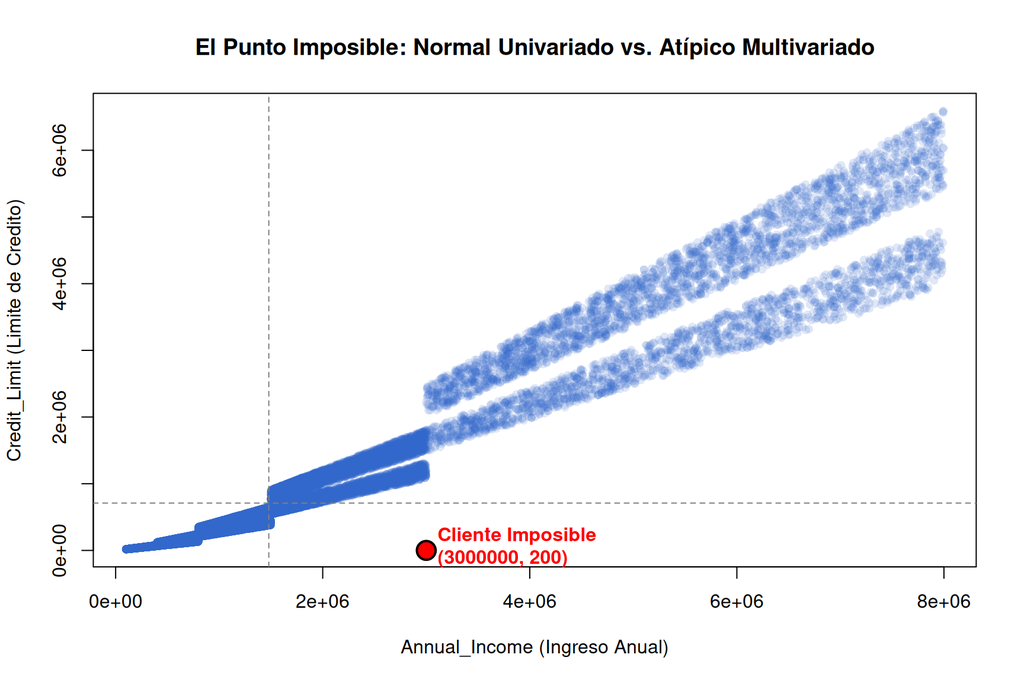

```r
plot(credit$Annual_Income, credit$Credit_Limit,
     pch = 16, col = rgb(0.2, 0.4, 0.8, 0.15),
     xlab = "Annual_Income (Ingreso Anual)",
     ylab = "Credit_Limit (Limite de Credito)",
     main = "El Punto Imposible: Normal Univariado vs. Atípico Multivariado")

# Dibujamos el punto en rojo
points(punto_ai, punto_cl, col = "red", pch = 19, cex = 2.2)
points(punto_ai, punto_cl, col = "black", pch = 1, cex = 2.2, lwd = 2)
text(punto_ai, punto_cl - 20000, labels = "Cliente Imposible\n(3000000, 200)", col = "red", font = 2, pos = 4)

# Cuadrantes de referencia
abline(v = mean(credit$Annual_Income), col = "gray50", lty = 2)
abline(h = mean(credit$Credit_Limit), col = "gray50", lty = 2)
```

# 8 Módulo 7: Estructura Multivariada Conjunta (S01 & S03)

## 8.1 Matriz de correlaciones completa ($\mathbf{R}$)

Calculamos la matriz de correlación entre variables estratégicas de negocio:

```r
vars_interes <- c("Annual_Income", "Credit_Limit", "Monthly_Spending",
                  "Outstanding_Balance", "Statement_Balance", "Payment_Amount",
                  "Payment_Ratio", "Credit_Utilization", "Reward_Points_Earned", "Credit_Score")

mat_cor <- cor(credit_num[, vars_interes], use = "complete.obs")
round(mat_cor, 3)
```

```
#>                      Annual_Income Credit_Limit Monthly_Spending
#> Annual_Income                1.000        0.974            0.945
#> Credit_Limit                 0.974        1.000            0.940
#> Monthly_Spending             0.945        0.940            1.000
#> Outstanding_Balance          0.843        0.866            0.814
#> Statement_Balance            0.874        0.894            0.855
#> Payment_Amount               0.819        0.839            0.805
#> Payment_Ratio                0.002        0.001            0.003
#> Credit_Utilization           0.005        0.005            0.005
#> Reward_Points_Earned         0.924        0.958            0.980
#> Credit_Score                 0.032        0.035            0.033
#>                      Outstanding_Balance Statement_Balance Payment_Amount
#> Annual_Income                      0.843             0.874          0.819
#> Credit_Limit                       0.866             0.894          0.839
#> Monthly_Spending                   0.814             0.855          0.805
#> Outstanding_Balance                1.000             0.997          0.932
#> Statement_Balance                  0.997             1.000          0.936
#> Payment_Amount                     0.932             0.936          1.000
#> Payment_Ratio                     -0.002            -0.001          0.192
#> Credit_Utilization                 0.293             0.262          0.246
#> Reward_Points_Earned               0.830             0.866          0.815
#> Credit_Score                      -0.145            -0.125          0.031
#>                      Payment_Ratio Credit_Utilization Reward_Points_Earned
#> Annual_Income                0.002              0.005                0.924
#> Credit_Limit                 0.001              0.005                0.958
#> Monthly_Spending             0.003              0.005                0.980
#> Outstanding_Balance         -0.002              0.293                0.830
#> Statement_Balance           -0.001              0.262                0.866
#> Payment_Amount               0.192              0.246                0.815
#> Payment_Ratio                1.000              0.005                0.003
#> Credit_Utilization           0.005              1.000                0.005
#> Reward_Points_Earned         0.003              0.005                1.000
#> Credit_Score                 0.767             -0.599                0.036
#>                      Credit_Score
#> Annual_Income               0.032
#> Credit_Limit                0.035
#> Monthly_Spending            0.033
#> Outstanding_Balance        -0.145
#> Statement_Balance          -0.125
#> Payment_Amount              0.031
#> Payment_Ratio               0.767
#> Credit_Utilization         -0.599
#> Reward_Points_Earned        0.036
#> Credit_Score                1.000
```

## 8.2 Matriz de dispersión multivariada (`pairs`)

Visualizamos las relaciones bivariadas simultáneas:

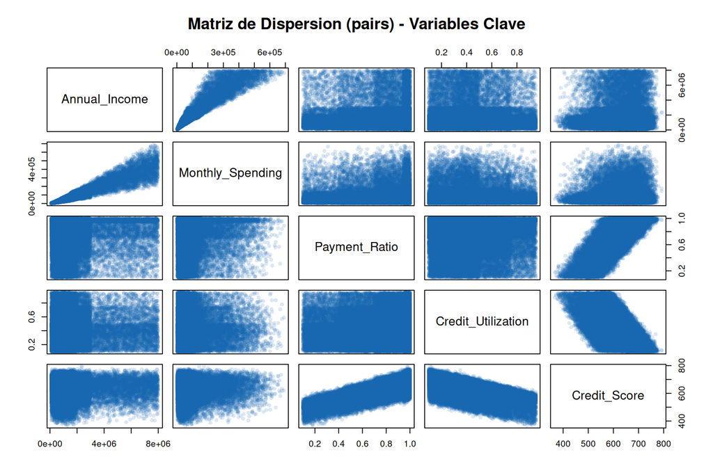

```r
vars_pairs <- c("Annual_Income", "Monthly_Spending", "Payment_Ratio",
                "Credit_Utilization", "Credit_Score")

pairs(credit_num[, vars_pairs],
      pch = 16,
      col = rgb(0.1, 0.4, 0.7, 0.15),
      main = "Matriz de Dispersion (pairs) - Variables Clave")
```

Siguiente parte de variables de interes

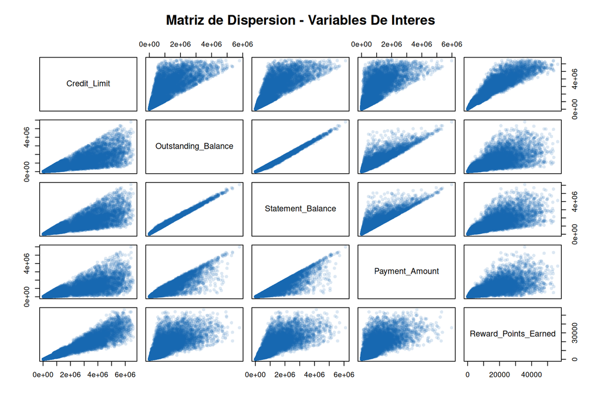

```r
vars_impairs <- c("Credit_Limit", "Outstanding_Balance", "Statement_Balance", "Payment_Amount", "Reward_Points_Earned")

pairs(credit[, vars_impairs],
      pch = 16,
      col = rgb(0.1, 0.4, 0.7, 0.15),
      main = "Matriz de Dispersion - Variables De Interes")
```